# TP1

Lecture

```r
> PISA2018 <- read.csv("PISA2018subset.csv", stringsAsFactors = TRUE)
> FR2018 <- subset(PISA2018, country == "FRA")
> head(FR2018)
```

```
     year country school_id student_id mother_educ father_educ gender computer
1151 2018     FRA  25000225   25005078 ISCED 3B, C ISCED 3B, C female      yes
1152 2018     FRA  25000027   25003747    ISCED 3A    ISCED 3A   male      yes
1153 2018     FRA  25000099   25000048    ISCED 3A    ISCED 3A female      yes
1154 2018     FRA  25000107   25002517 ISCED 3B, C ISCED 3B, C   male      yes
1155 2018     FRA  25000067   25003324 ISCED 3B, C     ISCED 2 female      yes
1156 2018     FRA  25000098   25004054    ISCED 3A     ISCED 2   male      yes
     internet    math    read science   stu_wgt desk room dishwasher television
1151      yes 427.984 429.264 498.480 143.50911  yes   no         NA         3+
1152      yes 564.981 480.485 577.435 133.70600  yes  yes         NA         3+
1153      yes 576.741 588.521 533.485 128.85403  yes  yes         NA          2
1154      yes 461.719 359.132 431.081  98.12940  yes  yes         NA          2
1155      yes 437.941 484.987 525.540 118.81755  yes  yes         NA         3+
1156      yes 396.839 372.606 362.503  28.46415  yes  yes         NA          2
     computer_n car    book  wealth    escs
1151         3+   1    0-10  0.2958 -0.8120
1152         3+   2 101-200  0.0424  0.7209
1153          2   2 201-500 -0.2961  0.3567
1154          1   2  26-100 -0.3888  0.0369
1155          0   1    0-10 -0.4048 -0.8459
1156          2   1  26-100 -0.5700 -0.1689
```

```r
> View(FR2018)
```

## Question 1

```r
> summary(FR2018)
```

```
      year         country     school_id         student_id
 Min.   :2018   FRA    :50   Min.   :2.5e+07   Min.   :25000001
 1st Qu.:2018   ALB    : 0   1st Qu.:2.5e+07   1st Qu.:25001396
 Median :2018   ARE    : 0   Median :2.5e+07   Median :25002778
 Mean   :2018   ARG    : 0   Mean   :2.5e+07   Mean   :25002971
 3rd Qu.:2018   AUS    : 0   3rd Qu.:2.5e+07   3rd Qu.:25004624
 Max.   :2018   AUT    : 0   Max.   :2.5e+07   Max.   :25007167
                (Other): 0
           mother_educ           father_educ    gender   computer internet
                 : 2                   : 0   female:29      : 0      : 1
 ISCED 1         : 1   ISCED 1         : 1   male  :21   no : 2   no : 0
 ISCED 2         : 4   ISCED 2         : 8               yes:48   yes:49
 ISCED 3A        :29   ISCED 3A        :22
 ISCED 3B, C     :14   ISCED 3B, C     :18
 less than ISCED1: 0   less than ISCED1: 1

      math            read          science         stu_wgt         desk
 Min.   :275.2   Min.   :270.1   Min.   :249.3   Min.   :  3.287      : 2
 1st Qu.:443.3   1st Qu.:429.6   1st Qu.:428.9   1st Qu.:119.610   no : 0
 Median :491.5   Median :488.1   Median :500.8   Median :125.739   yes:48
 Mean   :485.5   Mean   :478.9   Mean   :481.2   Mean   :119.963
 3rd Qu.:539.9   3rd Qu.:552.7   3rd Qu.:552.8   3rd Qu.:134.391
 Max.   :662.0   Max.   :641.6   Max.   :620.8   Max.   :158.629

  room    dishwasher     television computer_n car                book
    : 0   Mode:logical     : 0        : 0        : 1                : 0
 no : 5   NA's:50        0 : 1      0 : 2      0 : 2   0-10         : 6
 yes:45                  1 : 9      1 :12      1 :12   101-200      :10
                         2 :15      2 :19      2 :18   11-25        :12
                         3+:25      3+:17      3+:17   201-500      : 7
                                                       26-100       :14
                                                       more than 500: 1
     wealth              escs
 Min.   :-2.58010   Min.   :-3.14200
 1st Qu.:-0.55170   1st Qu.:-0.55693
 Median : 0.08680   Median : 0.00185
 Mean   :-0.03333   Mean   :-0.03044
 3rd Qu.: 0.45898   3rd Qu.: 0.61745
 Max.   : 1.43770   Max.   : 1.26500
```

```r
> colnames(FR2018)
```

```
 [1] "year"        "country"     "school_id"   "student_id"  "mother_educ"
 [6] "father_educ" "gender"      "computer"    "internet"    "math"
[11] "read"        "science"     "stu_wgt"     "desk"        "room"
[16] "dishwasher"  "television"  "computer_n"  "car"         "book"
[21] "wealth"      "escs"
```

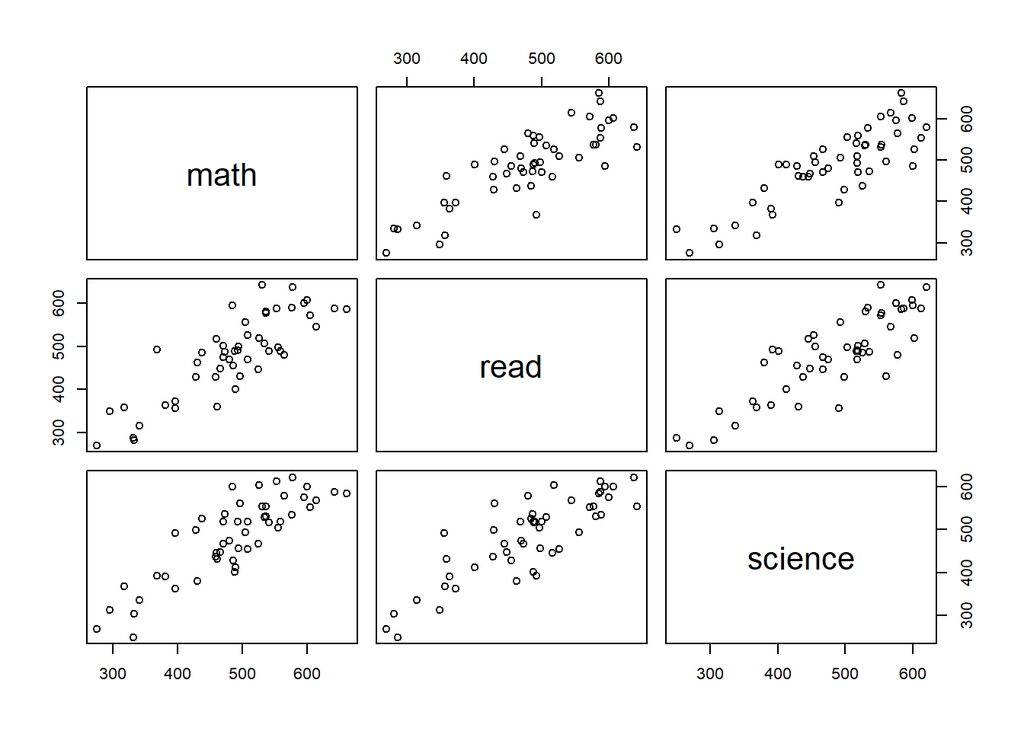

```r
> # la relation conjointe entres les scores math , read , science :
>
> pairs(FR2018[,c("math" ,"read" , "science")])
```

```r
> summary(FR2018)
```

```
      year         country     school_id         student_id
 Min.   :2018   FRA    :50   Min.   :2.5e+07   Min.   :25000001
 1st Qu.:2018   ALB    : 0   1st Qu.:2.5e+07   1st Qu.:25001396
 Median :2018   ARE    : 0   Median :2.5e+07   Median :25002778
 Mean   :2018   ARG    : 0   Mean   :2.5e+07   Mean   :25002971
 3rd Qu.:2018   AUS    : 0   3rd Qu.:2.5e+07   3rd Qu.:25004624
 Max.   :2018   AUT    : 0   Max.   :2.5e+07   Max.   :25007167
                (Other): 0
           mother_educ           father_educ    gender   computer internet
                 : 2                   : 0   female:29      : 0      : 1
 ISCED 1         : 1   ISCED 1         : 1   male  :21   no : 2   no : 0
 ISCED 2         : 4   ISCED 2         : 8               yes:48   yes:49
 ISCED 3A        :29   ISCED 3A        :22
 ISCED 3B, C     :14   ISCED 3B, C     :18
 less than ISCED1: 0   less than ISCED1: 1

      math            read          science         stu_wgt         desk
 Min.   :275.2   Min.   :270.1   Min.   :249.3   Min.   :  3.287      : 2
 1st Qu.:443.3   1st Qu.:429.6   1st Qu.:428.9   1st Qu.:119.610   no : 0
 Median :491.5   Median :488.1   Median :500.8   Median :125.739   yes:48
 Mean   :485.5   Mean   :478.9   Mean   :481.2   Mean   :119.963
 3rd Qu.:539.9   3rd Qu.:552.7   3rd Qu.:552.8   3rd Qu.:134.391
 Max.   :662.0   Max.   :641.6   Max.   :620.8   Max.   :158.629

  room    dishwasher     television computer_n car                book
    : 0   Mode:logical     : 0        : 0        : 1                : 0
 no : 5   NA's:50        0 : 1      0 : 2      0 : 2   0-10         : 6
 yes:45                  1 : 9      1 :12      1 :12   101-200      :10
                         2 :15      2 :19      2 :18   11-25        :12
                         3+:25      3+:17      3+:17   201-500      : 7
                                                       26-100       :14
                                                       more than 500: 1
     wealth              escs
 Min.   :-2.58010   Min.   :-3.14200
 1st Qu.:-0.55170   1st Qu.:-0.55693
 Median : 0.08680   Median : 0.00185
 Mean   :-0.03333   Mean   :-0.03044
 3rd Qu.: 0.45898   3rd Qu.: 0.61745
 Max.   : 1.43770   Max.   : 1.26500
```

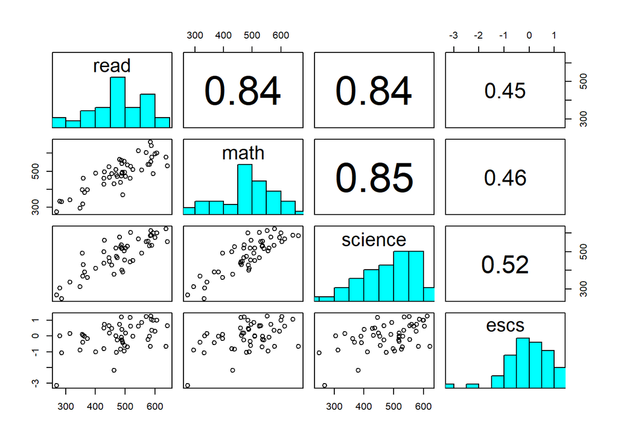

```r
> panel.hist <- function(x, ...)
+ {
+     usr <- par("usr")
+     par(usr = c(usr[1:2], 0, 1.5) )
+     h <- hist(x, plot = FALSE)
+     breaks <- h$breaks; nB <- length(breaks)
+     y <- h$counts; y <- y/max(y)
+     rect(breaks[-nB], 0, breaks[-1], y, col = "cyan", ...)
+ }
> panel.cor <- function(x, y, digits = 2, prefix = "", cex.cor, ...)
+ {
+     par(usr = c(0, 1, 0, 1))
+     r <- abs(cor(x, y))
+     txt <- format(c(r, 0.123456789), digits = digits)[1]
+     txt <- paste0(prefix, txt)
+     if(missing(cex.cor)) cex.cor <- 0.8/strwidth(txt)
+     text(0.5, 0.5, txt, cex = cex.cor * r)
+ }
>
>
> pairs(FR2018[,c("read", "math", "science", "escs")], diag.panel = panel.hist, upper.panel = panel.cor)
```

## Question 2

Utiliser `cor`, `lm(math~read, data=FR2018)`, `summary(lm())`, `abline(lm())`.

```r
> # Is the score in math explained by the score in read?
>
> # on peut utiliser cor :
> cor(FR2018$read , FR2018$math)
```

```
[1] 0.838203
```

```r
> # régression linéaire :
>
> lm.math.read <- lm(math~read , data = FR2018)
> summary(lm.math.read)
```

```
Call:
lm(formula = math ~ read, data = FR2018)

Residuals:
     Min       1Q   Median       3Q      Max
-128.522  -29.367   -0.856   30.067   91.995

Coefficients:
             Estimate Std. Error t value Pr(>|t|)
(Intercept) 103.96168   36.50438   2.848  0.00646 **
read          0.79664    0.07481  10.648 3.11e-14 ***
---
Signif. codes:  0 '***' 0.001 '**' 0.01 '*' 0.05 '.' 0.1 ' ' 1

Residual standard error: 49.49 on 48 degrees of freedom
Multiple R-squared:  0.7026,    Adjusted R-squared:  0.6964
F-statistic: 113.4 on 1 and 48 DF,  p-value: 3.111e-14
```

comme le coefficient de détermination du modéle de regression `lm(math~read)` est égale à 70% donc le pourcentege explique par ce modéle est trés imporatnt donc on peut dire que le score de math peut étre explique par le score de read

### Visulaistion du Modéle

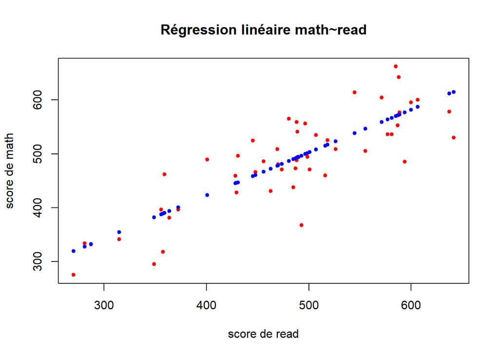

```r
> plot(FR2018$read , FR2018$math , col="red" , pch=20 ,
+      main = "Régression linéaire math~read" , xlab="score de read" , ylab="score de math")
>
> points(FR2018$read , fitted.values(lm.math.read) , col="blue" , pch=20 )
```

## Question 3

Utiliser `cor`, `lm(science~read, data=FR2018)`, `summary(lm())`, `abline(lm())`.

```r
> # est ce que on peut expliquer le score de science par le score de math :
>
> # on peut calculer le correlation entre science et read :
> cor(FR2018$science , FR2018$read)
```

```
[1] 0.8441456
```

```r
> # Régression linéaire entre science et read :
>
> lm.science.read <- lm(science ~ read , data = FR2018)
>
> summary(lm.science.read)
```

```
Call:
lm(formula = science ~ read, data = FR2018)

Residuals:
     Min       1Q   Median       3Q      Max
-100.863  -35.371   -0.777   27.516  119.122

Coefficients:
            Estimate Std. Error t value Pr(>|t|)
(Intercept) 83.49102   37.14473   2.248   0.0292 *
read         0.83044    0.07613  10.909 1.36e-14 ***
---
Signif. codes:  0 '***' 0.001 '**' 0.01 '*' 0.05 '.' 0.1 ' ' 1

Residual standard error: 50.36 on 48 degrees of freedom
Multiple R-squared:  0.7126,    Adjusted R-squared:  0.7066
F-statistic:   119 on 1 and 48 DF,  p-value: 1.36e-14
```

Comme le coefficient de détermination du modéle de regression `lm(science~read)` est égale à 71% donc le pourcentege explique par ce modéle est trés imporatnt donc on peut dire que le score de science peut étre explique par le score de read.

### Visulaistion du modéle

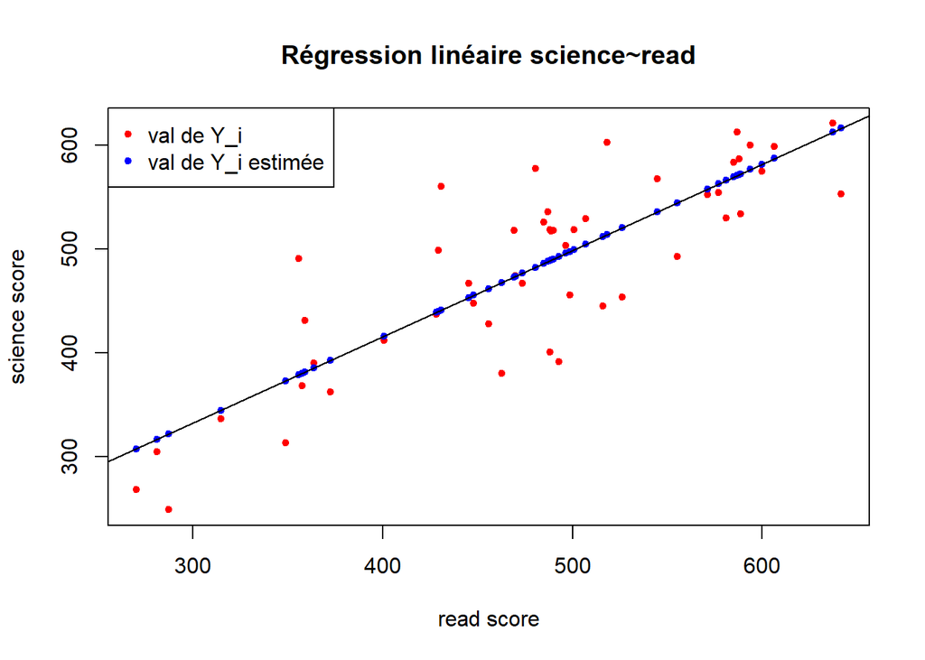

```r
> plot(FR2018$read , FR2018$science , col="red" , pch=20 ,
+      main="Régression linéaire science~read" , xlab="read score" , ylab="science score")
> points(FR2018$read , fitted.values(lm.science.read) , col="blue" , pch=20)
> legend("topleft", legend=c("val de Y_i" , "val de Y_i estimée") , col=c("red" , "blue") , pch=c(20 , 20))
> abline(lm.science.read)
```

## Question 4 : ??

- pour expliquer la reélation entre le score math , scie,ce et read il faut effecuter un régression linéaire multiple et il ne suffit d’effecuer le régression entre le modéle de régression entre chacun de ces modéle

## Question 5

Utiliser `cor`, `lm(math~escs, data=FR2018)`, `summary(lm())`, `abline(lm())`.

```r
> # We want to adjust the estimation against the socio-eonomic group escs of the family. Perform the
> # regression of math against escs. Display data and the regression line and discuss the part of the
> # explained variance
>
> lm.math.esc <- lm(math~escs , data = FR2018)
> summary(lm.math.esc)
```

```
Call:
lm(formula = math ~ escs, data = FR2018)

Residuals:
     Min       1Q   Median       3Q      Max
-153.898  -50.026    6.887   57.798  207.124

Coefficients:
            Estimate Std. Error t value Pr(>|t|)
(Intercept)   486.91      11.43  42.613  < 2e-16 ***
escs           47.53      13.37   3.555 0.000862 ***
---
Signif. codes:  0 '***' 0.001 '**' 0.01 '*' 0.05 '.' 0.1 ' ' 1

Residual standard error: 80.75 on 48 degrees of freedom
Multiple R-squared:  0.2084,    Adjusted R-squared:  0.1919
F-statistic: 12.64 on 1 and 48 DF,  p-value: 0.0008617
```

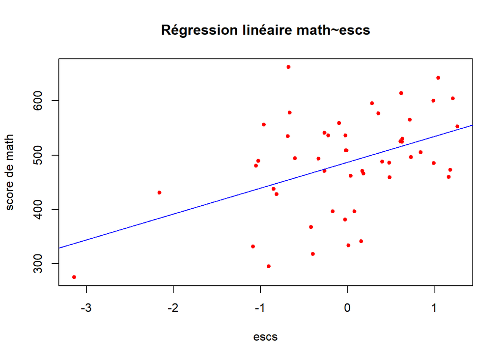

```r
> plot(FR2018$escs , FR2018$math , col="red" , pch=20 ,
+      main = "Régression linéaire math~escs" , xlab="escs" , ylab="score de math")
>
> abline(lm.math.esc , col="blue")
```

la varinace expliquée par ce modéle est trés faible donc le modéle n’est pas pectinate.

## Question 6

Utiliser `cor`, `lm(read~escs, data=FR2018)`, `summary(lm())`, `abline(lm())`.

```r
> #  Is the score in read linked to escs? Perform the regression of read against escs. Display the regression
> # line and discuss the part of the explained variance.
>
> # cor :
> cor(FR2018$read , FR2018$escs) # 0.44
```

```
[1] 0.4452782
```

```r
> # Régression lineaire entre read et escs :
> lm.read.escs <- lm(read ~ escs , data = FR2018)
> summary(lm.read.escs)
```

```
Call:
lm(formula = read ~ escs, data = FR2018)

Residuals:
    Min      1Q  Median      3Q     Max
-199.89  -55.55   12.15   54.10  189.31

Coefficients:
            Estimate Std. Error t value Pr(>|t|)
(Intercept)   480.37      12.10  39.703  < 2e-16 ***
escs           48.78      14.16   3.445  0.00119 **
---
Signif. codes:  0 '***' 0.001 '**' 0.01 '*' 0.05 '.' 0.1 ' ' 1

Residual standard error: 85.5 on 48 degrees of freedom
Multiple R-squared:  0.1983,    Adjusted R-squared:  0.1816
F-statistic: 11.87 on 1 and 48 DF,  p-value: 0.001194
```

la varinace expliquée par ce modéle est trés faible donc ce modéle n’est pertinente .

### Visualistion du modéle

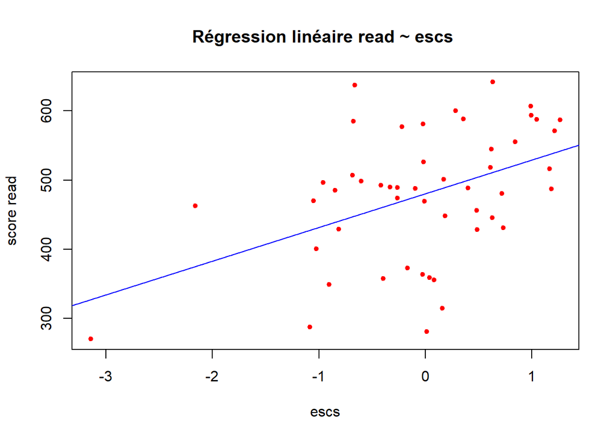

```r
> plot(FR2018$escs , FR2018$read , col="red" , pch=20 ,
+      main ="Régression linéaire read ~ escs " , xlab="escs" , ylab = "score read")
> abline(lm.read.escs , col="blue")
```

## Question 7

Utiliser `cor`, `lm(math~read+escs, data=FR2018)`, `summary(lm())`, `abline(lm())`.

```r
> lm.math <- lm(math~read+escs , data = FR2018)
> summary(lm.math)
```

```
Call:
lm(formula = math ~ read + escs, data = FR2018)

Residuals:
     Min       1Q   Median       3Q      Max
-123.719  -22.208    0.944   33.987  103.615

Coefficients:
            Estimate Std. Error t value Pr(>|t|)
(Intercept) 125.3403    40.5713   3.089  0.00336 **
read          0.7527     0.0832   9.047 7.33e-12 ***
escs         10.8129     9.1137   1.186  0.24141
---
Signif. codes:  0 '***' 0.001 '**' 0.01 '*' 0.05 '.' 0.1 ' ' 1

Residual standard error: 49.28 on 47 degrees of freedom
Multiple R-squared:  0.7112,    Adjusted R-squared:  0.6989
F-statistic: 57.88 on 2 and 47 DF,  p-value: 2.103e-13
```

### RQ :

```r
> confint(lm.math , "escs" , level = 0.95 )
```

```
         2.5 %  97.5 %
escs -7.521448 29.1472
```

avce un niveau de coffiance de 95% on que 0 apparient à l’intervalle de coffiance de escs donc le choix de ce varibable dans le modéle de régression n’approte pas de gande information .

## Question 8

# Boxplot

```r
> summary(FR2018$gender)
```

```
female   male
    29     21
```

Utiliser `boxplot(math ~ gender, data = FR2018)`, `shapiro.test`, `t.test`

```r
> math.score.fille <- FR2018$math[FR2018$gender == "female"]
> math.score.fille
```

```
 [1] 427.984 576.741 437.941 555.979 486.231 485.542 505.456 524.920 530.411
[10] 466.253 536.566 540.950 275.231 595.851 662.023 536.651 470.750 381.686
[19] 525.605 460.160 459.518 471.064 472.801 509.107 488.223 600.634 367.964
[28] 494.184 604.495
```

```r
> math.score.garcon <- FR2018$math[FR2018$gender == "male"]
> math.score.garcon
```

```
 [1] 564.981 461.719 396.839 534.662 295.651 489.500 480.225 508.882 396.472
[10] 496.681 552.715 333.613 642.493 318.230 578.440 559.149 614.290 493.446
[19] 331.871 341.215 431.281
```

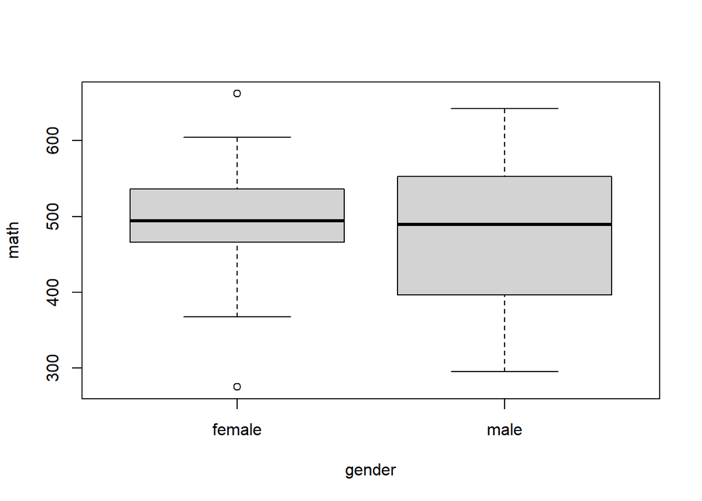

```r
> boxplot(math ~ gender  ,data = FR2018 )
```

### Interprétations :

- On remarque que la ligne médiane est presque égale pour les notes de filles en mathématiques et les notes de garçons en mathématiques ont presque la même médiane.
- On remarque que les notes de filles présentent des valeurs aberrantes.
- La taille de la boîte des garçons est plus longue que celle des filles, ce qui explique une variabilité importante des notes de garçons.

# t.test && shapiro.test :

- shapiro.test : La fonction shapiro.test en R est utilisée pour effectuer un test de normalité de Shapiro-Wilk. Ce test évalue si un échantillon de données suit une distribution normale.

```r
> shapiro.test(FR2018$math)
```

```
    Shapiro-Wilk normality test

data:  FR2018$math
W = 0.97089, p-value = 0.2515
```

le p-value de ce test est 25% donc on ne peut pas réjeter l’hypothése de normalité de score de math donc on peut appliquer le test de stuent entre les scores de math pour les filles et le score math pour les garçons .

- t.test : La fonction `t.test` en R est utilisée pour effectuer un test t de Student afin de comparer les moyennes de deux groupes indépendants. Ce test est couramment utilisé pour déterminer si les moyennes de deux échantillons indépendants sont statistiquement différentes.

```r
> t.test(math ~ gender , data =FR2018)
```

```
    Welch Two Sample t-test

data:  math by gender
t = 1.1409, df = 35.593, p-value = 0.2615
alternative hypothesis: true difference in means between group female and group male is not equal to 0
95 percent confidence interval:
 -23.79855  84.95141
sample estimates:
mean in group female   mean in group male
            498.3076             467.7312
```

comme le p-value égale à 26% donc on ne peut pas réjetre l’hypothése H0 .

## Question 9

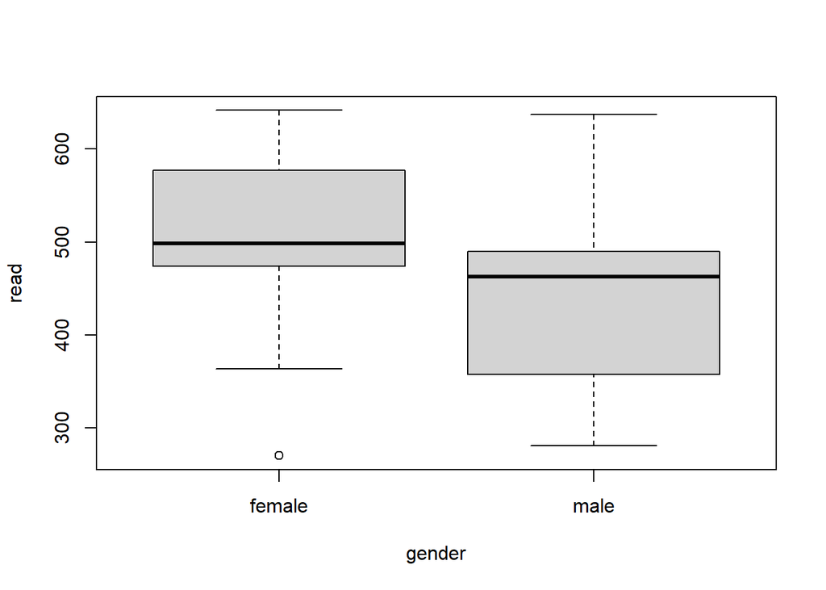

```r
> # Same question for the score in read for FR2018
>
> # boxplot :
> boxplot(read ~ gender , data = FR2018)
```

```r
> shapiro.test(FR2018$read)
```

```
    Shapiro-Wilk normality test

data:  FR2018$read
W = 0.95941, p-value = 0.08395
```

```r
> mean(FR2018$read[FR2018$gender =="male"]) # 439.6356
```

```
[1] 439.6356
```

```r
> mean(FR2018$read[FR2018$gender =="female"]) # 507.3138
```

```
[1] 507.3138
```

## Question 10

Changer `FR2018` en `PISA2018`.

```r
> country <- unique(PISA2018$country)
> mean.fille <- rep(0 , length(country))
> mean.gar <- rep(0 , length(country))
> i <- 1
>
> for( e in country) {
+   mean.gar[i] <- mean(PISA2018$read[PISA2018$country == e & PISA2018$gender =="male"])
+   mean.fille[i] <- mean(PISA2018$read[PISA2018$country == e & PISA2018$gender=="female"])
+   i <- i + 1
+ }
>
> df <- data.frame(
+   country= unique(PISA2018$country) ,
+   gar = mean.gar ,
+   fille = mean.fille
+ )
>
> df$fille_sup_gar <- df$fille > df$gar
> View(df)
>
>
> summary(df$fille_sup_gar)
```

```
   Mode   FALSE    TRUE    NA's
logical      12      66       2
```

donc on remarque que en génerle les filles sont trés forte en lecteur (66 country ).